*Transport Analytics Training Series - Last Revision: October 2022*

# Working with Network Datasets

Now that we have covered the basics of networkx, and we can start experimenting with "real" network files. In this section, we will be using the classical Sioux Falls network layout, which is very frequently used as a 'toy' network in the academic transportation literature.

In this particular notebook, we are also going to carry out a fair amount of data manipulation, and for this reason we will also need to use the `pandas` library. We can make sure that it has been properly installed using the below command.

```python
!pip install pandas
```

`pandas` will only be used to import and manage the data contained in the external files. Any network manipulation activities will require`networkx` - which we also need to import, as before.

```python
import networkx as nx
import pandas as pd
```

A common convention when importing `pandas` is to use the `pd` acronym.

### Part 1 - Loading external files

I have placed the relevant datasets in a separate folder. The network structure is expressed as a series of csv files, which we can easily read using the `pd.read_csv()` command, which returns a "dataframe" that contains the information in the file.

```python
links = pd.read_csv('data-sioux-falls/siouxfalls_links.csv')
links
```

|  | from_node | to_node | length |
| --- | --- | --- | --- |
| 0 | 1 | 2 | 6 |
| 1 | 1 | 3 | 4 |
| 2 | 2 | 1 | 6 |
| 3 | 2 | 6 | 5 |
| 4 | 3 | 1 | 4 |
| ... | ... | ... | ... |
| 71 | 23 | 22 | 4 |
| 72 | 23 | 24 | 2 |
| 73 | 24 | 13 | 4 |
| 74 | 24 | 21 | 3 |
| 75 | 24 | 23 | 2 |

76 rows × 3 columns

As you can notice above, `pandas` is able to recognise the labels in our csv file, and uses them to name the columns. Its algorithms, however, is not foolproof - occasionally you might need to intervene.

```python
nodes = pd.read_csv('data-sioux-falls/siouxfalls_nodes.csv')
nodes
```

|  | node | x | y |
| --- | --- | --- | --- |
| 0 | 1 | -96.770420 | 43.612828 |
| 1 | 2 | -96.711251 | 43.605813 |
| 2 | 3 | -96.774303 | 43.572962 |
| 3 | 4 | -96.747168 | 43.563654 |
| 4 | 5 | -96.731569 | 43.564034 |
| 5 | 6 | -96.711644 | 43.587586 |
| 6 | 7 | -96.693423 | 43.563844 |
| 7 | 8 | -96.711382 | 43.562324 |
| 8 | 9 | -96.731241 | 43.548596 |
| 9 | 10 | -96.731438 | 43.545271 |
| 10 | 11 | -96.746841 | 43.544131 |
| 11 | 12 | -96.780137 | 43.543941 |
| 12 | 13 | -96.793377 | 43.490707 |
| 13 | 14 | -96.751035 | 43.529306 |
| 14 | 15 | -96.731504 | 43.529401 |
| 15 | 16 | -96.711382 | 43.546744 |
| 16 | 17 | -96.711382 | 43.541280 |
| 17 | 18 | -96.694078 | 43.546744 |
| 18 | 19 | -96.711316 | 43.529591 |
| 19 | 20 | -96.711185 | 43.515333 |
| 20 | 21 | -96.730979 | 43.510485 |
| 21 | 22 | -96.731241 | 43.514858 |
| 22 | 23 | -96.750904 | 43.514858 |
| 23 | 24 | -96.749200 | 43.503164 |

We don't need to add all these edges to a graph one by one - we can simply create a list of edges and supply them to `networkx`.

To do this, we will use the `zip()` command which is used to take separate lists of objects (with the same number of items) and join them in a single object. The two lists that we wish to join is the sequence of origin nodes (`from_node`)and the sequence of destination nodes (`to_node`) in our pandas dataframe.

The resulting object that is returned by th `zip` function cannot be used directly, but must rather converted into a list using the `list()` command.

```python
new_links = list(zip(links['from_node'], links['to_node']))
new_links
```

```
[(1, 2),
 (1, 3),
 (2, 1),
 (2, 6),
 (3, 1),
 (3, 4),
 (3, 12),
 (4, 3),
 (4, 5),
 (4, 11),
 (5, 4),
 (5, 6),
 (5, 9),
 (6, 2),
 (6, 5),
 (6, 8),
 (7, 8),
 (7, 18),
 (8, 6),
 (8, 7),
 (8, 9),
 (8, 16),
 (9, 5),
 (9, 8),
 (9, 10),
 (10, 9),
 (10, 11),
 (10, 15),
 (10, 16),
 (10, 17),
 (11, 4),
 (11, 10),
 (11, 12),
 (11, 14),
 (12, 3),
 (12, 11),
 (12, 13),
 (13, 12),
 (13, 24),
 (14, 11),
```

[output cut: 21 more lines]

```
 (20, 21),
 (20, 22),
 (21, 20),
 (21, 22),
 (21, 24),
 (22, 15),
 (22, 20),
 (22, 21),
 (22, 23),
 (23, 14),
 (23, 22),
 (23, 24),
 (24, 13),
 (24, 21),
 (24, 23)]
```

We are now ready too proceed:

```python
G = nx.Graph()
G.add_nodes_from(nodes['node'])
G.add_edges_from(new_links)
```

This is a lot more compact than the first graph that we generated. In the first instance we passed a list of node IDs to the `add_nodes_from` function, that were contained in the `nodes['node']` column. NetworkX used these IDs to create new node objects.

The list of links was also passed to NetworkX. The resulting network is:

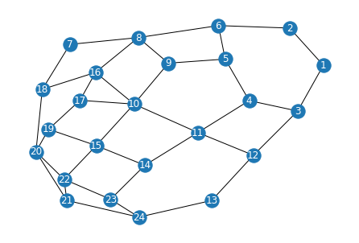

```python
nx.draw(G, with_labels = True, font_color = 'white')
```

Contrary to the abstract graphs that we experimented with earlier, this relates to a civil infrastructure network and it would be therefore quite important to represent its spatial structure accurately.

To achieve this, we need to create a list of node parameters. We can do that by zipping the relevant columns in the nodes dataframe. In contrast to the sequence of edge colors that we used before, this needs to be served to `networkx` as a dictionary, with the keys being the node IDs and the values being the coordinates.

```python
coords = list(zip(nodes['x'], nodes['y']))
pos = dict(zip(nodes['node'], coords))
pos
```

```
{1: (-96.77041974, 43.61282792),
 2: (-96.71125063, 43.60581298),
 3: (-96.77430341, 43.5729616),
 4: (-96.74716843, 43.56365362),
 5: (-96.73156909, 43.56403357),
 6: (-96.71164389, 43.58758553),
 7: (-96.69342281, 43.5638436),
 8: (-96.71138171, 43.56232379),
 9: (-96.73124137, 43.54859634),
 10: (-96.73143801, 43.54527088),
 11: (-96.74684071, 43.54413068),
 12: (-96.78013678, 43.54394065),
 13: (-96.79337655, 43.49070718),
 14: (-96.75103549, 43.52930613),
 15: (-96.73150355, 43.52940117),
 16: (-96.71138171, 43.54674361),
 17: (-96.71138171, 43.54128009),
 18: (-96.69407825, 43.54674361),
 19: (-96.71131617, 43.52959125),
 20: (-96.71118508, 43.5153335),
 21: (-96.7309792, 43.51048509),
 22: (-96.73124137, 43.51485818),
 23: (-96.75090441, 43.51485818),
 24: (-96.74920028, 43.50316422)}
```

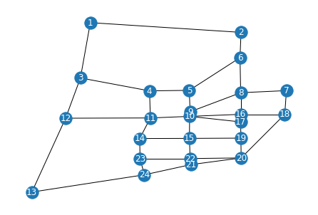

```python
nx.draw(G, pos, with_labels = True, font_color = 'white')
```

We can now start experimenting with the paths again - we pick two nodes (13 and 7), and can call the `nx.dijkstra_path_length()` command to get the length of the shortest path, as calculated by the Dijkstras algorithm implementation provided by `networkx`.

```python
nx.dijkstra_path_length(G, source=13, target=7)
```

```
5
```

The algorithm reports that the length of the shortest path is 5. Looking at the list of edges that we loaded, it is reasonable to suspect that something is not right.

### Part 2 - Visualizing shortest paths

Let's visualize the path:

```python
path = nx.dijkstra_path(G, source=13, target=7)
path
```

```
[13, 24, 21, 20, 18, 7]
```

We can now plot it using the same approach that we followed above.

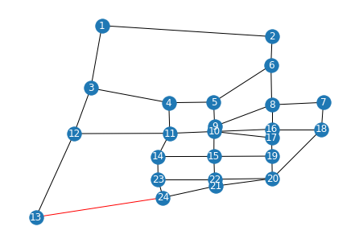

```python
edges_path = list(zip(path,path[1:]))
edge_colors = ['red' if edge in edges_path else 'black' for edge in G.edges()]
nx.draw(G, pos, with_labels = True, edge_color= edge_colors, font_color = 'white')
```

We can only see one highlighted line in the graph, and this certainly does not suffice to connect 13 to 7. After all, the shortest path had several nodes, and we would have expected to see several edges highlighted.

Let us look at the variables one by one.

```python
edges_path
```

```
[(13, 24), (24, 21), (21, 20), (20, 18), (18, 7)]
```

Everything appears to be OK here.

```python
edge_colors
```

```
['black',
 'black',
 'black',
 'black',
 'black',
 'black',
 'black',
 'black',
 'black',
 'black',
 'black',
 'black',
 'black',
 'black',
 'black',
 'black',
 'black',
 'black',
 'black',
 'black',
 'black',
 'black',
 'red',
 'black',
 'black',
 'black',
 'black',
 'black',
 'black',
 'black',
 'black',
 'black',
 'black',
 'black',
 'black',
 'black',
 'black',
 'black']
```

We are getting closer - only one node is highlighted. The problem must be located at the command used to generate this list:

```
edge_colors = ['red' if edge in edges_path else 'black' for edge in G.edges()]
```

Let's look at the lists of variables that we are comparing, `G.edges()` and `edges_path`.

```python
G.edges()
```

```
EdgeView([(1, 2), (1, 3), (2, 6), (3, 4), (3, 12), (4, 5), (4, 11), (5, 6), (5, 9), (6, 8), (7, 8), (7, 18), (8, 9), (8, 16), (9, 10), (10, 11), (10, 15), (10, 16), (10, 17), (11, 12), (11, 14), (12, 13), (13, 24), (14, 15), (14, 23), (15, 19), (15, 22), (16, 17), (16, 18), (17, 19), (18, 20), (19, …
```

```python
edges_path
```

```
[(13, 24), (24, 21), (21, 20), (20, 18), (18, 7)]
```

We have spotted the problem. Even though our graph is bidirectional, the code that we wrote to highlight the edges does not "understand" the concepts of bi-directionality. It simply checks the edges as reported by `networkx`.

There are many ways to resolve this - for the time being we will use something quick and dirty: we will add to the `edges_path` the reversed versions of all edges. This way we will ensure that the edge will be highlighted.

We can start by creating a list of the reversed edges:

```python
edges_path_reversed = [(y,x) for (x,y) in edges_path]
edges_path_reversed
```

```
[(24, 13), (21, 24), (20, 21), (18, 20), (7, 18)]
```

We now append them to the list:

```python
edges_path = edges_path + edges_path_reversed
edges_path
```

```
[(13, 24),
 (24, 21),
 (21, 20),
 (20, 18),
 (18, 7),
 (24, 13),
 (21, 24),
 (20, 21),
 (18, 20),
 (7, 18)]
```

Let's try again!

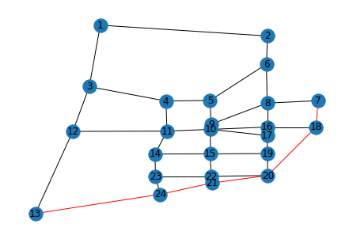

```python
edge_colors = ['red' if edge in edges_path else 'black' for edge in G.edges()]
nx.draw(G, pos, with_labels = True, edge_color= edge_colors)
```

Success!

But this is only one of the problems that we encountered... If you might recall, we also need to find out why the shortest path is so short.

The Dijkstra's algorithm provided by `networkx` calculates the paths using the `weight` property of each edge. We can inspect this using this following command:

```python
G.edges.data("weight")
```

```
EdgeDataView([(1, 2, None), (1, 3, None), (2, 6, None), (3, 4, None), (3, 12, None), (4, 5, None), (4, 11, None), (5, 6, None), (5, 9, None), (6, 8, None), (7, 8, None), (7, 18, None), (8, 9, None), (8, 16, None), (9, 10, None), (10, 11, None), (10, 15, None), (10, 16, None), (10, 17, None), (11, 12…
```

Uh, but of course! We never added the lenghts that were included in the links dataframe to the graph.

```python
weights = dict(zip(G.edges,links['length']))
weights
```

```
{(1, 2): 6,
 (1, 3): 4,
 (2, 6): 6,
 (3, 4): 5,
 (3, 12): 4,
 (4, 5): 4,
 (4, 11): 4,
 (5, 6): 4,
 (5, 9): 2,
 (6, 8): 6,
 (7, 8): 2,
 (7, 18): 4,
 (8, 9): 5,
 (8, 16): 5,
 (9, 10): 4,
 (10, 11): 2,
 (10, 15): 3,
 (10, 16): 2,
 (10, 17): 2,
 (11, 12): 3,
 (11, 14): 10,
 (12, 13): 5,
 (13, 24): 5,
 (14, 15): 10,
 (14, 23): 3,
 (15, 19): 3,
 (15, 22): 5,
 (16, 17): 6,
 (16, 18): 4,
 (17, 19): 8,
 (18, 20): 6,
 (19, 20): 5,
 (20, 21): 6,
 (20, 22): 4,
 (21, 22): 4,
 (21, 24): 6,
 (22, 23): 3,
 (23, 24): 3}
```

```python
nx.set_edge_attributes(G, values = weights, name = 'weight')
G.edges.data("weight")
```

```
EdgeDataView([(1, 2, 6), (1, 3, 4), (2, 6, 6), (3, 4, 5), (3, 12, 4), (4, 5, 4), (4, 11, 4), (5, 6, 4), (5, 9, 2), (6, 8, 6), (7, 8, 2), (7, 18, 4), (8, 9, 5), (8, 16, 5), (9, 10, 4), (10, 11, 2), (10, 15, 3), (10, 16, 2), (10, 17, 2), (11, 12, 3), (11, 14, 10), (12, 13, 5), (13, 24, 5), (14, 15, 10…
```

Much better. Let's try again.

```python
nx.dijkstra_path_length(G, source=13, target=7)
```

```
19
```

This looks more like it! Let's visualise the shortest path:

```python
path = nx.dijkstra_path(G, source=13, target=7)
path
```

```
[13, 12, 11, 10, 16, 8, 7]
```

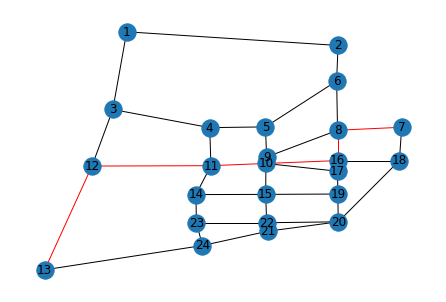

```python
edges_path = list(zip(path,path[1:]))
edges_path_reversed = [(y,x) for (x,y) in edges_path]
edges_path = edges_path + edges_path_reversed
edge_colors = ['red' if edge in edges_path else 'black' for edge in G.edges()]
nx.draw(G, pos, with_labels = True, edge_color= edge_colors)
```

So, the path is actually different from the one that we obtained before - it turns out that when a weight is not provided, Dijkstra's uses a default weight of 1.

### Part 3 - All-to-all shortest paths

What if we wanted to obtain all the shortest paths in our network?

```python
all_paths = dict(nx.all_pairs_dijkstra_path(G))
all_paths
```

```
{1: {1: [1],
  2: [1, 2],
  3: [1, 3],
  4: [1, 3, 4],
  12: [1, 3, 12],
  6: [1, 2, 6],
  11: [1, 3, 12, 11],
  13: [1, 3, 12, 13],
  5: [1, 3, 4, 5],
  10: [1, 3, 12, 11, 10],
  14: [1, 3, 12, 11, 14],
  8: [1, 2, 6, 8],
  24: [1, 3, 12, 13, 24],
  9: [1, 3, 4, 5, 9],
  15: [1, 3, 12, 11, 10, 15],
```

[output cut: 561 more lines]

As we can see from the above, the `all_pairs_dijkstra_path` function returns a nested dictionary (dict-of-dicts), that contains the sequence of shortest paths between any two nodes in the network.

An important detail in the above is that we had to use the `dict` funtion ahead of `all_pairs_dijkstra_path`. This is because by default, the ltter function will return a "generator" object, which produces specific paths between node pairs only when requested. The `dict` ensures that all the paths are calculated and saved into a dictionary, in our case `all_paths`.

**WARNING**: The above operation is likely going to take a lot of time in a very large network.

Having calculated all paths in a single go and stored them into a nested dictionary, we can obtain our shortest paths as follows:

```python
all_paths[24][10]
```

```
[24, 23, 22, 15, 10]
```

And if we wanted to "flatten" the dictionary and obtain all individual paths, we can use the following:

```python
path_list = []      #initialises empty list of paths

for i in all_paths:
    for j in all_paths[i]:
        path_list.append(all_paths[i][j])

len(path_list)
```

```
576
```

If we look closer at a random path in that set, we can notice that it is provided to us as a sequence of nodes.

```python
sample_path=path_list[10]
sample_path
```

```
[1, 3, 12, 11, 14]
```

Using the same command that we used in our visualisation function, we can convert this into a list of links (node pairs)

```python
edges_path = list(zip(sample_path,sample_path[1:]))
edges_path
```

```
[(1, 3), (3, 12), (12, 11), (11, 14)]
```

As we saw before, for a list of all edges in the network, we can use the `edges()` function in our graph object:

```python
all_edges = list(G.edges())
all_edges
```

```
[(1, 2),
 (1, 3),
 (2, 6),
 (3, 4),
 (3, 12),
 (4, 5),
 (4, 11),
 (5, 6),
 (5, 9),
 (6, 8),
 (7, 8),
 (7, 18),
 (8, 9),
 (8, 16),
 (9, 10),
 (10, 11),
 (10, 15),
 (10, 16),
 (10, 17),
 (11, 12),
 (11, 14),
 (12, 13),
 (13, 24),
 (14, 15),
 (14, 23),
 (15, 19),
 (15, 22),
 (16, 17),
 (16, 18),
 (17, 19),
 (18, 20),
 (19, 20),
 (20, 21),
 (20, 22),
 (21, 22),
 (21, 24),
 (22, 23),
 (23, 24)]
```

Now, let's assume that we want to calculate the number of shortest paths that contain each link.

```python
path_counts = {}  # Initializes an empty dictionary
```

```python
for i in all_edges:
    path_counts[i] = 0

path_counts
```

```
{(1, 2): 0,
 (1, 3): 0,
 (2, 6): 0,
 (3, 4): 0,
 (3, 12): 0,
 (4, 5): 0,
 (4, 11): 0,
 (5, 6): 0,
 (5, 9): 0,
 (6, 8): 0,
 (7, 8): 0,
 (7, 18): 0,
 (8, 9): 0,
 (8, 16): 0,
 (9, 10): 0,
 (10, 11): 0,
 (10, 15): 0,
 (10, 16): 0,
 (10, 17): 0,
 (11, 12): 0,
 (11, 14): 0,
 (12, 13): 0,
 (13, 24): 0,
 (14, 15): 0,
 (14, 23): 0,
 (15, 19): 0,
 (15, 22): 0,
 (16, 17): 0,
 (16, 18): 0,
 (17, 19): 0,
 (18, 20): 0,
 (19, 20): 0,
 (20, 21): 0,
 (20, 22): 0,
 (21, 22): 0,
 (21, 24): 0,
 (22, 23): 0,
 (23, 24): 0}
```

In our next step, we would go through our list of paths, convert each of them into a sequence of edges, and then keep track of how many times each of them is encountered:

```python
for path in path_list:                        # go through each path in our list of paths
    edges_sequence = list(zip(path,path[1:])) # convert the sequence of nodes to a sequence of edges

    for edge in edges_sequence:               # now go through each edge in our sequence of edges
        path_counts[edge] += 1                # increment our edge incidence counter by one
```

```
---------------------------------------------------------------------------
KeyError                                  Traceback (most recent call last)
Input In [34], in <cell line: 1>()
      2 edges_sequence = list(zip(path,path[1:])) # convert the sequence of nodes to a sequence of edges
      4 for edge in edges_sequence:               # now go through each edge in our sequence of edges
----> 5     path_counts[edge] += 1

KeyError: (12, 11)
```

It was a good approach in theory, but we encountered the same problem as before! Because our graph is bidirectional, an edge can be traversed in either direction. We can see that the loop above wanted to increment our counter for edge (12, 11), but such an key could not be found in our dictionary.

It did however contain an edge (11, 12). We will use a work-around: before incrementing the value in the dictionary, we will be checking whether the edge exists as a key. If it does not, we will assume that the reverse edge exists, and we will be incrementing that value instead.

**Note**: This issue will not have occured in a directed graph.

```python
for path in path_list:                        # go through each path in our list of paths
    edges_sequence = list(zip(path,path[1:])) # convert the sequence of nodes to a sequence of edges

    for edge in edges_sequence:               # now go through each edge in our sequence of edges
        i,j = edge

        if (i,j) in path_counts.keys():
            path_counts[(i,j)] += 1                # increment our edge incidence counter by one
        else:
            path_counts[(j,i)] += 1                # increment our edge incidence counter by one

path_counts
```

```
{(1, 2): 24,
 (1, 3): 56,
 (2, 6): 37,
 (3, 4): 19,
 (3, 12): 74,
 (4, 5): 42,
 (4, 11): 46,
 (5, 6): 50,
 (5, 9): 74,
 (6, 8): 24,
 (7, 8): 44,
 (7, 18): 30,
 (8, 9): 16,
 (8, 16): 42,
 (9, 10): 80,
 (10, 11): 124,
 (10, 15): 146,
 (10, 16): 90,
 (10, 17): 42,
 (11, 12): 106,
 (11, 14): 30,
 (12, 13): 60,
 (13, 24): 38,
 (14, 15): 4,
 (14, 23): 20,
 (15, 19): 54,
 (15, 22): 86,
 (16, 17): 0,
 (16, 18): 26,
 (17, 19): 4,
 (18, 20): 38,
 (19, 20): 28,
 (20, 21): 10,
 (20, 22): 26,
 (21, 22): 26,
 (21, 24): 10,
 (22, 23): 68,
 (23, 24): 46}
```

That looks like a very interesting set of counts. If we wanted to sort the dictionary by value, we could use the following:

```python
import operator


sorted_counts = dict( sorted(path_counts.items(), key=operator.itemgetter(1),reverse=True))
sorted_counts
```

```
{(10, 15): 146,
 (10, 11): 124,
 (11, 12): 106,
 (10, 16): 90,
 (15, 22): 86,
 (9, 10): 80,
 (3, 12): 74,
 (5, 9): 74,
 (22, 23): 68,
 (12, 13): 60,
 (1, 3): 56,
 (15, 19): 54,
 (5, 6): 50,
 (4, 11): 46,
 (23, 24): 46,
 (7, 8): 44,
 (4, 5): 42,
 (8, 16): 42,
 (10, 17): 42,
 (13, 24): 38,
 (18, 20): 38,
 (2, 6): 37,
 (7, 18): 30,
 (11, 14): 30,
 (19, 20): 28,
 (16, 18): 26,
 (20, 22): 26,
 (21, 22): 26,
 (1, 2): 24,
 (6, 8): 24,
 (14, 23): 20,
 (3, 4): 19,
 (8, 9): 16,
 (20, 21): 10,
 (21, 24): 10,
 (14, 15): 4,
 (17, 19): 4,
 (16, 17): 0}
```